# Demand Forecasting Model for Hotel Bookings

## Time Series Analysis with Python

by [**Nosheen Altaf**](https://www.linkedin.com/in/nosheen-altaf-565158a/)

## Time Series Introduction:

A **Time Series** is a series of data points ordered in time where time is often the independent variable

**Time Series Analysis** comprises methods for analyzing time series data to extract meaningful statistics and other features of the data

**Time Series Forecasting** is the use of a model to predict future values based on previously observed values

**Time Series Models:**

There are many ways to model a time series to make predictions i-e Moving Average, Exponential Smoothing etc.

Three broad classes of practical importance are the

**1. The Autoregressive (AR) Models:**

An autoregressive (AR) model predicts future behavior based on past behavior. The process is basically a linear regression of the data in the current series against one or more past values in the same series

**2. The Integrated (I) Models:**

The order of integration, denoted I(d), of a time series is the minimum number of differences required to obtain a stationary series

**3. The Moving Average (MA) Models:**

MA model depends on the errors(residuals) of the previous forecasts to make current forecasts

*Combinations of these Models produce autoregressive moving average (ARMA) and autoregressive integrated moving average (ARIMA) models etc.*

**Component of Time Series:**

Also know as **ETS** :

**E** refers to Error (unsystematic, short term fluctuations),

**T** refers to Trend(long term direction) and

**S** refers to Seasonality(systematic, calendar related movements).

Lastly, a **cyclical pattern** is a result of some external factors which make them much harder to predict. Cycles do not have fixed periods, they may range from six to ten years

**Stationary Time Series:**

A time series is said to be stationary if it has constant mean and variance, and covariance is independent of time.

## Get the Data

```python
import pandas as pd
import numpy as np
import matplotlib.pyplot as plt
%matplotlib inline
```

```python
df=pd.read_excel('bookings.xlsx')
```

## Data Investigation

Lets get familiar with our data by viewing it!

We will examine if the data is complete without any null values, there is no inconsistency in different level of categorical variables, variable info ,variable type etc.

```python
df.head() #first 5 rows
```

|  | Year | Month | Bookings |
| --- | --- | --- | --- |
| 0 | 2006 | Jan | 383 |
| 1 | 2006 | Feb | 366 |
| 2 | 2006 | Mar | 250 |
| 3 | 2006 | Apr | 318 |
| 4 | 2006 | May | 334 |

```python
df.tail() #last 5 rows
```

|  | Year | Month | Bookings |
| --- | --- | --- | --- |
| 115 | 2015 | Aug | 18478 |
| 116 | 2015 | Sep | 12004 |
| 117 | 2015 | Oct | 9789 |
| 118 | 2015 | Nov | 10003 |
| 119 | 2015 | Dec | 13304 |

```python
len(df) #total number of observations
```

```
120
```

```python
df.isnull().sum() #to check null values
```

```
Year        0
Month       0
Bookings    0
dtype: int64
```

```python
df[['Year','Month']].groupby('Year').count() #to see if we have any missing month value in any year
```

| Year | Month |
| --- | --- |
| 2006 | 12 |
| 2007 | 12 |
| 2008 | 12 |
| 2009 | 12 |
| 2010 | 12 |
| 2011 | 12 |
| 2012 | 12 |
| 2013 | 12 |
| 2014 | 12 |
| 2015 | 12 |

```python
df['Month'].unique() #to see if there is any inconsistency in month's name
```

```
array(['Jan', 'Feb', 'Mar', 'Apr', 'May', 'Jun', 'Jul', 'Aug', 'Sep',
       'Oct', 'Nov', 'Dec'], dtype=object)
```

## Data Preparation

### Setting Date Time Index

```python
df.info()
```

```
<class 'pandas.core.frame.DataFrame'>
RangeIndex: 120 entries, 0 to 119
Data columns (total 3 columns):
Year        120 non-null int64
Month       120 non-null object
Bookings    120 non-null int64
dtypes: int64(2), object(1)
memory usage: 2.9+ KB
```

If we look at the data info, there is no date time index in our data.

To take advantage of some built in methods, we need to have a date time index.

Lets create a date time index for our data.

```python
import statsmodels.api as sm
```

```python
index1=pd.Index(sm.tsa.datetools.dates_from_range('2006M1','2015M12'))
```

```python
df.index=index1
```

```python
df.index.freq='M' #lets set frequency to month
```

```python
df.index
```

```
DatetimeIndex(['2006-01-31', '2006-02-28', '2006-03-31', '2006-04-30',
               '2006-05-31', '2006-06-30', '2006-07-31', '2006-08-31',
               '2006-09-30', '2006-10-31',
               ...
               '2015-03-31', '2015-04-30', '2015-05-31', '2015-06-30',
               '2015-07-31', '2015-08-31', '2015-09-30', '2015-10-31',
               '2015-11-30', '2015-12-31'],
              dtype='datetime64[ns]', length=120, freq='M')
```

```python
df.info()
```

```
<class 'pandas.core.frame.DataFrame'>
DatetimeIndex: 120 entries, 2006-01-31 to 2015-12-31
Freq: M
Data columns (total 3 columns):
Year        120 non-null int64
Month       120 non-null object
Bookings    120 non-null int64
dtypes: int64(2), object(1)
memory usage: 3.8+ KB
```

We can now see our index is all set, lets review the head of the data one more time

```python
df.head()
```

|  | Year | Month | Bookings |
| --- | --- | --- | --- |
| 2006-01-31 | 2006 | Jan | 383 |
| 2006-02-28 | 2006 | Feb | 366 |
| 2006-03-31 | 2006 | Mar | 250 |
| 2006-04-30 | 2006 | Apr | 318 |
| 2006-05-31 | 2006 | May | 334 |

## Data Visualization

Lets explore the data by creating some visualizations

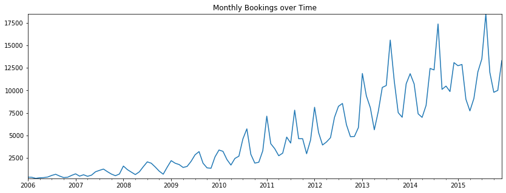

```python
ax=df['Bookings'].plot(title='Monthly Bookings over Time',figsize=(14,5))
ax.autoscale(axis='both',tight=True)
```

We can clearly see that our data is non stationary with a clear upward trend and seasonality.

## Month Plots

Lets see trend on different time intervals

```python
from statsmodels.graphics.tsaplots import month_plot, quarter_plot
```

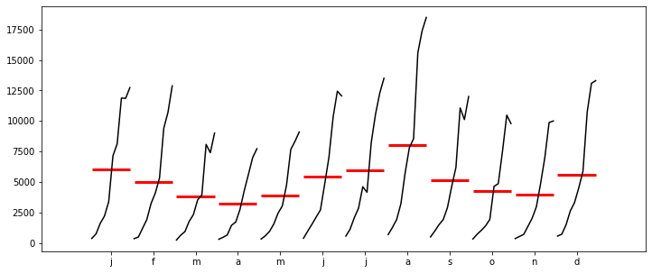

```python
from pylab import rcParams
rcParams['figure.figsize']=12,5
month_plot(df['Bookings']);
```

The above plot shows range of monthly values (i-e minimum and maximum for each month) with monthly average over years showing in red, we can clearly see average is high in August.

### Another Visualization of Month Plots

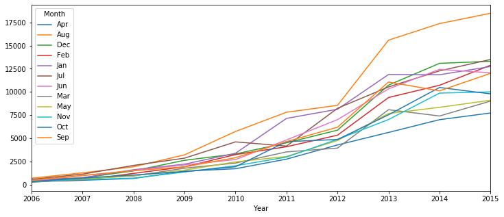

```python
pd.pivot_table(data=df, values='Bookings', index='Year', columns='Month').plot(figsize=(12,5));
```

We can note that Bookings for August are very high, looks like demand in month of August for this particular hotel is maximum. This is also an indication of Seasonality

## Quarter Plots

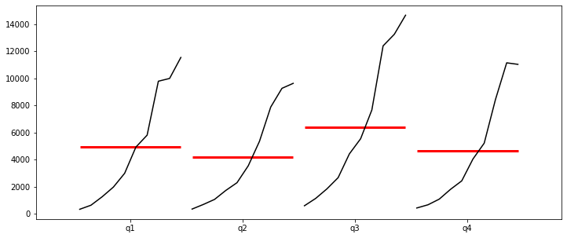

```python
dfq=df['Bookings'].resample(rule='Q').mean()
rcParams['figure.figsize']=12,5
quarter_plot(dfq);
```

We can clearly see that in each year, 3rd quarter sales/bookings are high

## Year Plots

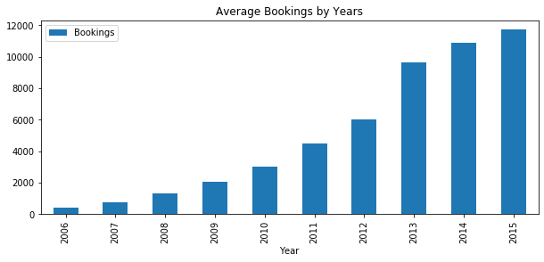

```python
df[['Bookings','Year']].groupby(['Year']).mean().plot(kind='bar',title='Average Bookings by Years',figsize=(10,4));
```

Yearly trend is increasing in a multiplicative manner

## Testing Hypothesis if Data is Stationary

Since we have observed that our data is non stationary. We can perform a hypothesis testing to confirm if data is stationary or not.

Lets perform Augmented Dickey-Fuller Test to see if data is stationary or not.

If p-value is less than 0.05, then our data is stationary

```python
from statsmodels.tsa.stattools import adfuller
```

```python
dftest=adfuller(df['Bookings'])
```

```python
dftest=pd.Series(dftest[0:4],index=['ADF Test Statistic','p-value','No.of lags','Total obs'])
```

```python
dftest
```

```
ADF Test Statistic      0.983756
p-value                 0.994092
No.of lags             13.000000
Total obs             106.000000
dtype: float64
```

High p-values is an indication that we are fail to reject our null hypothesis that our data is not stationary . so we have concluded that our data is not stationary, we can make it stationary by taking differencing and re run the test to confirm it.

## ETS Decomposition

We have now visualize that our hotel data has Trend and Seasonality. Now lets decompose the data to see error, trend and seasonality over time

```python
from statsmodels.tsa.seasonal import seasonal_decompose
```

```python
component=seasonal_decompose(df['Bookings'])
```

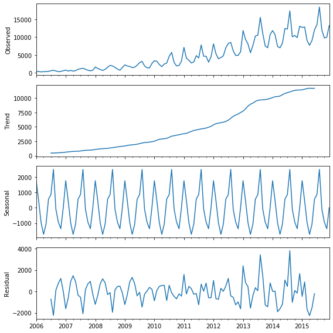

```python
rcParams['figure.figsize']=8,8
component.plot();
```

We can also visualize those plots individually as per below

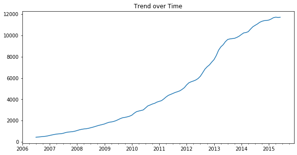

```python
component.trend.plot(title='Trend over Time' ,figsize=(10,5));
```

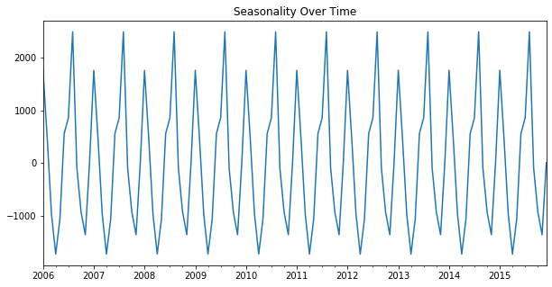

```python
component.seasonal.plot(title='Seasonality Over Time' ,figsize=(10,5));
```

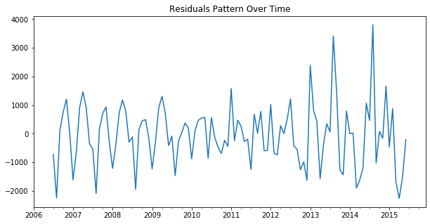

```python
component.resid.plot(title='Residuals Pattern Over Time' ,figsize=(10,5));
```

## Model Selection

Now we have concluded that our series is non stationary with error, trend and seasonality. ARIMA is a good choice to fit that kind of data. Since our data has seasonality , we will use seasonal ARIMA, also knows as SARIMA that supports the direct modeling of the seasonal component of the series.

Lets briefly describe SARIMA Models

SARIMA is specified as **SARIMA (p, d q)(P, D, Q)m** :

**p** is the number of time lags i-e an AR part

**d** is the degree of differencing

**q** is the order of Moving average model.

**P** is Seasonal autoregressive order.

**D** is Seasonal difference order.

**Q** is Seasonal moving average order.

**m** is The number of time steps for a single seasonal period

There are two ways to decide the order of p d q

**Method 1:**

We can decide p d q by reading the ACF and PACF plots, which is little difficult to read sometimes

**Method 2:**

Grid Search (i-e try different combination of SARIMA model and compare on some evaluation metrics)

## Plotting ACF and PACF

**ACF Plot:**

The ACF plot shows correlation of the series with itself,lagged by x time units, in general there is a decline (gradual or sharp)

Identification of MA model is often best done with the ACF rather than the PACF, if there is a gradual decline it suggest an MA model

**PACF Plot**:

The PACF only describes the direct relationship between an observation and its lag.

Identification of an AR model is often best done with PACF. Typically, a sharp drop after lag k suggests an AR-k model should be used.

Lets create ACF and PACF plots

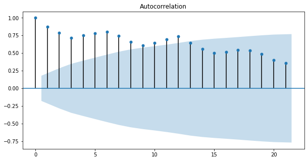

```python
from statsmodels.graphics.tsaplots import plot_acf,plot_pacf
rcParams['figure.figsize']=10,5
plot_acf(df['Bookings']);
```

The shaded region is 95% Confidence Interval, values outside of this shaded regions are highly correlated. Reading from ACF plot, it looks like Moving Average of order 1 to be included in our Model. Please note sometimes these plots are hard to read and model can have human error because of the wrong interpretation.

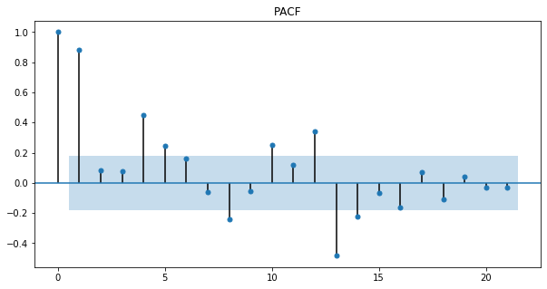

```python
plot_pacf(df['Bookings'],title='PACF');
```

Reading from PACF plot, it looks like an AR(1).

## Using Grid Search

Grid Search is a most effective and recommended way to decide the parameters of our model as it uses AIC (Akaike Information Criterion) and BIC(Bayesian Information Criterion) as a metric to compare the performance of various ARIMA based models.

## Train Test Split

We typically keep most recent *n* values as a hold out sample or test, and number of test periods should match the length of the forecast periods, i-e *n* test values to predict *n* future values.

We want to forecast the hotel booking for next 6 month, then our test data should have at least 6 observation.

We can make split by indexing

```python
train=df.iloc[:114]
test=df.iloc[113:]
```

```python
test # most recent 7 periods as a hold out data set
```

|  | Year | Month | Bookings |
| --- | --- | --- | --- |
| 2015-06-30 | 2015 | Jun | 12055 |
| 2015-07-31 | 2015 | Jul | 13496 |
| 2015-08-31 | 2015 | Aug | 18478 |
| 2015-09-30 | 2015 | Sep | 12004 |
| 2015-10-31 | 2015 | Oct | 9789 |
| 2015-11-30 | 2015 | Nov | 10003 |
| 2015-12-31 | 2015 | Dec | 13304 |

## Outline the Model

We will finalize the model parameters using Grid Search

```python
import warnings
warnings.filterwarnings('ignore')
```

```python
from pmdarima import auto_arima #Grid Search
```

```python
model_para=auto_arima(df['Bookings'],
           start_p=0,
           start_q=0,
           max_p=6,
           max_q=6,
           seasonal=True,
           trace=True,
           m=12)
```

```
Fit ARIMA: order=(0, 1, 0) seasonal_order=(1, 1, 1, 12); AIC=1844.922, BIC=1855.613, Fit time=0.131 seconds
Fit ARIMA: order=(0, 1, 0) seasonal_order=(0, 1, 0, 12); AIC=1854.058, BIC=1859.404, Fit time=0.016 seconds
Fit ARIMA: order=(1, 1, 0) seasonal_order=(1, 1, 0, 12); AIC=1814.089, BIC=1824.780, Fit time=0.302 seconds
Fit ARIMA: order=(0, 1, 1) seasonal_order=(0, 1, 1, 12); AIC=1802.915, BIC=1813.606, Fit time=0.434 seconds
Fit ARIMA: order=(0, 1, 1) seasonal_order=(1, 1, 1, 12); AIC=1802.461, BIC=1815.825, Fit time=1.063 seconds
Fit ARIMA: order=(0, 1, 1) seasonal_order=(1, 1, 0, 12); AIC=1800.642, BIC=1811.333, Fit time=0.792 seconds
Fit ARIMA: order=(0, 1, 1) seasonal_order=(2, 1, 1, 12); AIC=1805.123, BIC=1821.160, Fit time=1.861 seconds
Fit ARIMA: order=(1, 1, 1) seasonal_order=(1, 1, 0, 12); AIC=1802.439, BIC=1815.803, Fit time=0.633 seconds
Fit ARIMA: order=(0, 1, 0) seasonal_order=(1, 1, 0, 12); AIC=1842.039, BIC=1850.058, Fit time=0.181 seconds
Fit ARIMA: order=(0, 1, 2) seasonal_order=(1, 1, 0, 12); AIC=1802.491, BIC=1815.855, Fit time=0.827 seconds
Fit ARIMA: order=(1, 1, 2) seasonal_order=(1, 1, 0, 12); AIC=1803.098, BIC=1819.135, Fit time=2.361 seconds
Fit ARIMA: order=(0, 1, 1) seasonal_order=(0, 1, 0, 12); AIC=1810.667, BIC=1818.685, Fit time=0.265 seconds
Fit ARIMA: order=(0, 1, 1) seasonal_order=(2, 1, 0, 12); AIC=1802.308, BIC=1815.673, Fit time=2.717 seconds
Total fit time: 11.615 seconds
```

```python
model_para.summary()
```

Statespace Model Results

| Dep. Variable: | y | No. Observations: | 120 |
| --- | --- | --- | --- |
| Model: | SARIMAX(0, 1, 1)x(1, 1, 0, 12) | Log Likelihood | -896.321 |
| Date: | Fri, 15 Nov 2019 | AIC | 1800.642 |
| Time: | 17:59:00 | BIC | 1811.333 |
| Sample: | 0 | HQIC | 1804.976 |
|  | - 120 |  |  |
| Covariance Type: | opg |  |  |

|  | coef | std err | z | P>\|z\| | [0.025 | 0.975] |
| --- | --- | --- | --- | --- | --- | --- |
| intercept | 6.4290 | 27.887 | 0.231 | 0.818 | -48.228 | 61.086 |
| ma.L1 | -0.7425 | 0.060 | -12.400 | 0.000 | -0.860 | -0.625 |
| ar.S.L12 | -0.3336 | 0.070 | -4.798 | 0.000 | -0.470 | -0.197 |
| sigma2 | 1.098e+06 | 1.16e+05 | 9.441 | 0.000 | 8.7e+05 | 1.33e+06 |

| Ljung-Box (Q): | 46.22 | Jarque-Bera (JB): | 15.76 |
| --- | --- | --- | --- |
| Prob(Q): | 0.23 | Prob(JB): | 0.00 |
| Heteroskedasticity (H): | 25.27 | Skew: | 0.30 |
| Prob(H) (two-sided): | 0.00 | Kurtosis: | 4.78 |

Warnings:  
[1] Covariance matrix calculated using the outer product of gradients (complex-step).

So our model is SARIMA model with order (p=0,d=1,q=1)x(P=1,D=1,Q=0,m=12)

## Model Fitting

Now we have decided our model parameter, we can now fit the model to our train data and evaluate on the test data

```python
from statsmodels.tsa.statespace.sarimax import SARIMAX
```

```python
model=SARIMAX(train['Bookings'],
             order=(0, 1, 1),
             seasonal_order=(1, 1, 0, 12))
```

```python
model.fit().summary()
```

Statespace Model Results

| Dep. Variable: | Bookings | No. Observations: | 114 |
| --- | --- | --- | --- |
| Model: | SARIMAX(0, 1, 1)x(1, 1, 0, 12) | Log Likelihood | -848.178 |
| Date: | Fri, 15 Nov 2019 | AIC | 1702.356 |
| Time: | 17:59:27 | BIC | 1710.202 |
| Sample: | 01-31-2006 | HQIC | 1705.532 |
|  | - 06-30-2015 |  |  |
| Covariance Type: | opg |  |  |

|  | coef | std err | z | P>\|z\| | [0.025 | 0.975] |
| --- | --- | --- | --- | --- | --- | --- |
| ma.L1 | -0.7411 | 0.060 | -12.455 | 0.000 | -0.858 | -0.624 |
| ar.S.L12 | -0.3085 | 0.075 | -4.139 | 0.000 | -0.455 | -0.162 |
| sigma2 | 1.145e+06 | 1.26e+05 | 9.122 | 0.000 | 8.99e+05 | 1.39e+06 |

| Ljung-Box (Q): | 39.36 | Jarque-Bera (JB): | 13.89 |
| --- | --- | --- | --- |
| Prob(Q): | 0.50 | Prob(JB): | 0.00 |
| Heteroskedasticity (H): | 29.89 | Skew: | 0.29 |
| Prob(H) (two-sided): | 0.00 | Kurtosis: | 4.72 |

Warnings:  
[1] Covariance matrix calculated using the outer product of gradients (complex-step).

## Plot of Observed vs. Predicted Bookings

```python
start=len(train)-1
```

```python
end=len(df)-1
```

```python
predictions=model.fit().predict(start,end,typ='levels').rename('Predicted')
```

```python
pd.DataFrame(data=predictions.round(2))
```

|  | Predicted |
| --- | --- |
| 2015-06-30 | 13488.53 |
| 2015-07-31 | 13066.34 |
| 2015-08-31 | 18146.13 |
| 2015-09-30 | 11740.56 |
| 2015-10-31 | 10901.45 |
| 2015-11-30 | 10325.45 |
| 2015-12-31 | 13686.96 |

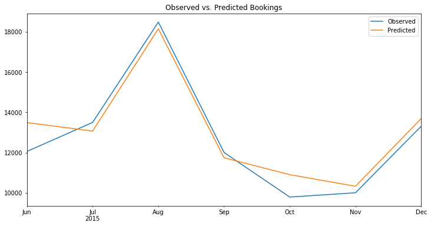

```python
test['Bookings'].rename('Observed').plot(figsize=(12,6),legend=True, title= 'Observed vs. Predicted Bookings')
predictions.plot(legend=True);
```

## Evaluation Metrics:

```python
from statsmodels.tools.eval_measures import rmse
```

```python
error=rmse(test['Bookings'],predictions)
```

```python
error
```

```
747.1226144107198
```

```python
train['Bookings'].std()
```

```
4111.095483168445
```

Since our fitted model RMSE is less than the standard deviation of training data (i-e **Baseline RMSE**), it is an indication that our Model is performing better

## Forecasting:

Let forecast next six month bookings for the year of 2016

```python
model1=SARIMAX(df['Bookings'],
              order=(0, 1, 1),
              seasonal_order=(1, 1, 0, 12))
```

```python
forecast=model1.fit().predict(end+1,len(df)+5,typ='levels').rename('6 Month Forecast')
```

```python
pd.DataFrame(data=forecast.round(2))
```

|  | 6 Month Forecast |
| --- | --- |
| 2016-01-31 | 13578.52 |
| 2016-02-29 | 13294.99 |
| 2016-03-31 | 9614.97 |
| 2016-04-30 | 8627.75 |
| 2016-05-31 | 9986.11 |
| 2016-06-30 | 13319.72 |

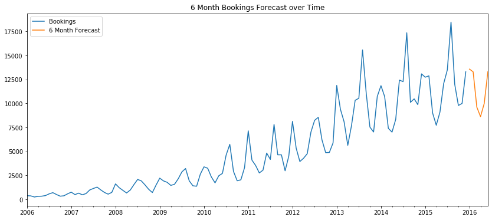

```python
df['Bookings'].plot(legend=True,figsize=(14,6),title='6 Month Bookings Forecast over Time')
forecast.plot(legend=True)
plt.show()
```

## Conclusion:

Seasonal ARIMA perform very well when working with a time series where data is directly related to the time stamp, such as airline passenger data set, hotel booking for a resort etc as we see clear growth and seasonality based on time.However, ARIMA is not suitable for stock price data as it has so many outside factors than the time stamp),just knowing the stock price over time isn't actually enough to predict stock price.

## References:

```
1.https://en.wikipedia.org/wiki/Time_series
2.https://www.udemy.com/course/python-for-time-series-data-analysis/
```